# Descriptive Analysis of Farmers in SAL-Database

## Number of Farmers in SAL-Database

```r
nrow(farm1.df)
```

```
[1] 341
```

The initial dataset consists of 341 farmers. These farmers are not all focused on livestock production.

## Number of Farmers with Livestock Production

```r
table(farmers.df$livestockproduction, useNA = "ifany")
```

```
FALSE  TRUE
  133   208
```

Only 208 farmers indicate that milk or meat is part of their production. The purpose of production differs however.

## Purpose of Meat Production

```r
table(farmers.df$purpose_meat)
```

```
Mayormente para venta y un poco para autoconsumo                     No lleva a cabo la actividad
                                               2                                              280
                              Otro (especificar)                                       Solo venta
                                               1                                               58
```

58 of farmers produce meat just for market. 280 of them do not at all produce meat.

## Purpose of Milk Production

```r
table(farmers.df$purpose_milk)
```

```
                                        Autoconsumo Mayormente para autoconsumo y un poco para la venta
                                                  3                                                   1
   Mayormente para venta y un poco para autoconsumo                        No lleva a cabo la actividad
                                                101                                                 170
                                         Solo venta
                                                 66
```

Milk for market and also partly for self-use is produced by 101. 66 only produce to sell and 170 do not at all produce milk.

The production form partly depends on the location.

## Livestock Production and Land-type

```r
table(farmers.df$livestockproduction, farmers.df$f1_landscape)
```

```
        Cordillera-Montaña Vega Piedemonte Lomerío (lomas, mesas y vallecitos Otro, ¿cuál?
  FALSE                 95    7          4                                 20            0
  TRUE                  43    9          7                                143            0

        Cordillera-montaña y piedemonte Cordillera-montaña y lomerío Vega y piedemonte Vega y lomerío
  FALSE                               2                            2                 2              0
  TRUE                                1                            2                 1              2

        Piedemonte y lomerio
  FALSE                    1
  TRUE                     0
```

Most non-livestock producing farmers are located in the mountainous region (Cordillera-Montaña). The hilly area (lomerío) is dominated by cattle ranchers.

For the purpose of this study the dataset was filtered for those farmers that have some kind of livestock production.

```r
livestock_farmers <- filter(farmers.df, livestockproduction==TRUE)
```

## Total Land Size of Livestock Producers

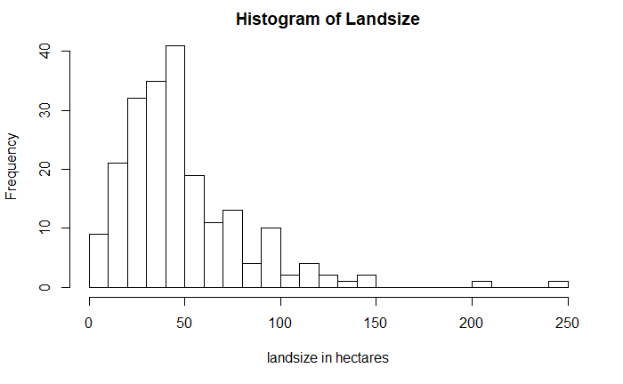

The livestock farmers had a mean land size of 49.96 hectares.

## Livestock Producers with Silvopastoral Systems

```r
table(livestock_farmers_na.omit$silvopastoral)
```

```
FALSE  TRUE
  107    17
```

# Applied Silvopastoral Systems

```r
summary(livestock_farmers[c("dispersed_trees", "forage_banks", "intense_sps", "living_fences", "trees_in_lines")])
```

```
 dispersed_trees forage_banks intense_sps living_fences trees_in_lines
   :  1            :  1         :  1      No:206          :  1
 No:185          No:193       No:201      Si:  2        No:188
 Si: 22          Si: 14       Si:  6                    Si: 19
```

The systems mostly used by farmers with silvopastoral systems are dispersed trees and trees in lines.

# Livestock

## Animal Units

```r
summary(farmers.df$tlu)
```

```
   Min. 1st Qu.  Median    Mean 3rd Qu.    Max.    NA's
  0.000   8.094  17.944  22.635  32.083 148.444     119
```

## Histogram of Animal Units

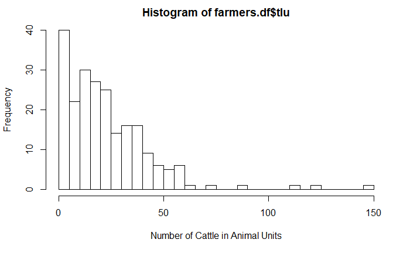

## Stocking Rates of Animal Units to Total Landsize

```r
summary(filter(livestock_farmers_na.omit, silvopastoral==FALSE)[,"stocking_rate_pasture_silvo"])
```

```
   Min. 1st Qu.  Median    Mean 3rd Qu.    Max.
 0.0000  0.4399  0.7007  1.2485  1.3230  9.3333
```

[figure not shown]

```r
summary(filter(livestock_farmers_na.omit, silvopastoral==TRUE)[,"stocking_rate_pasture_silvo"])
```

```
   Min. 1st Qu.  Median    Mean 3rd Qu.    Max.
 0.0000  0.2339  0.7452  2.1809  1.8611 16.7238
```

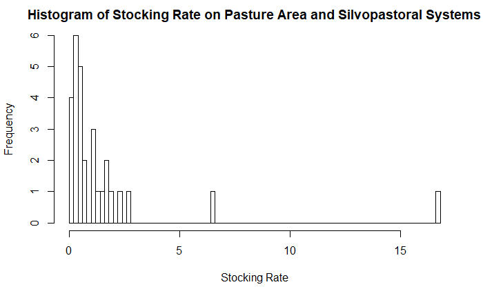

The Median silvopastoral farmer has a slightly higher stocking rate than the conventional farmer. The mean stocking rate almost doubles for silvopastoralfarmers.